# Crecimiento del turismo receptivo

En abril de este año el turismo receptivo en Argentina superó el nivel del mismo mes prepandemia.

## El camino de la recuperación del turismo internacional en el mundo

La pandemia de COVID-19 tuvo en el turismo internacional uno de los impactos más severos y perdurables. Las llegadas de turistas internacionales a nivel mundial tuvo una caída interanual del 72,2% en 2020, del 68,9% en 2021 y 34,3% en 2022 contra el año 2019. En Sudamérica, por su parte, el desplome de las llegadas de turistas fue más profundo, especialmente en el año 2021: la caída respecto de 2019 fue de 72,4% ,85% y 38,8% en el trienio 2020-2022. El primer trimestre del año 2023 muestra una tendencia a la reducción de la caída, pero aún no logra alcanzar los niveles previos a la crisis: -20,4% para el Mundo y -18,3% para Sudamérica respecto del primer trimestre de 2019.[^1]

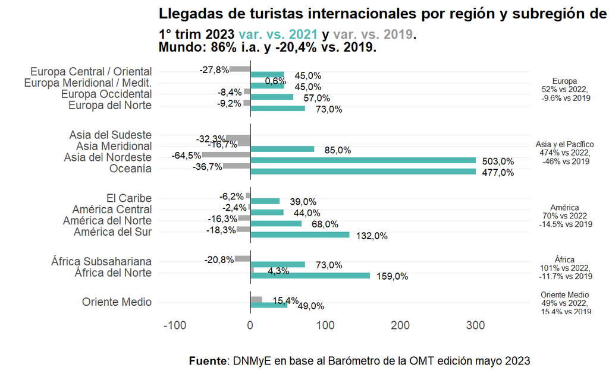

## La situación regional del turismo receptivo internacional

En la región Argentina se destaca como uno de los países con mejor desempeño en la recuperación del turismo receptivo internacional durante el primer trimestre de 2023. Es el primer país en el ranking de recuperación respecto a igual trimestre de 2019 en términos de turistas con un valor del 87,9% y el segundo en términos de visitantes con una recuperación del 109,4%, superando el nivel del primer trimestre 2019.

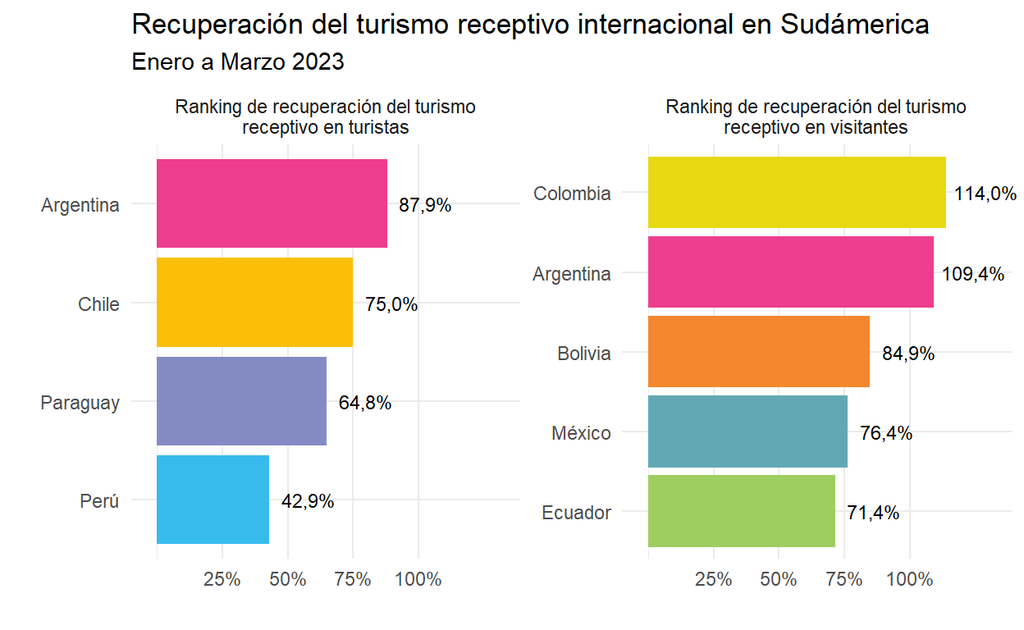

## Evolución del turismo receptivo internacional en Argentina

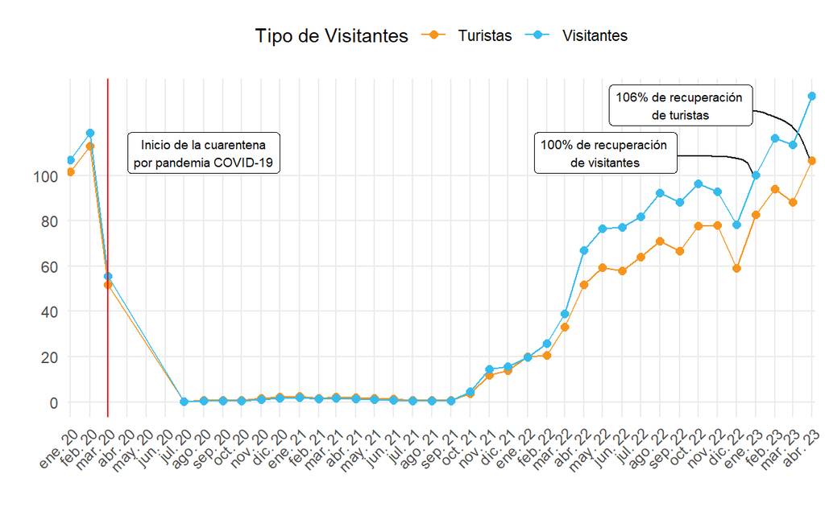

[^1]: los datos surgen de la compilación que hace la Organización Mundial del Turismo (OMT), publicados en el último Barómetro del Turismo Mundial (edición mayo 2023)